# Web scrapping with Rvest

Cricket has always been the most popular sport in India. Some people are just obsessed with ‘numbers’. From most ‘number’ of runs scored to most ‘number’ of wickets taken and the list goes on. I haven’t followed cricket for a while now, might come as a surprise, considering that i live in a cricket frenzy nation. It wasn’t until recently i started following the sport again, i was curious to find out which players have been doing well and which weren’t.

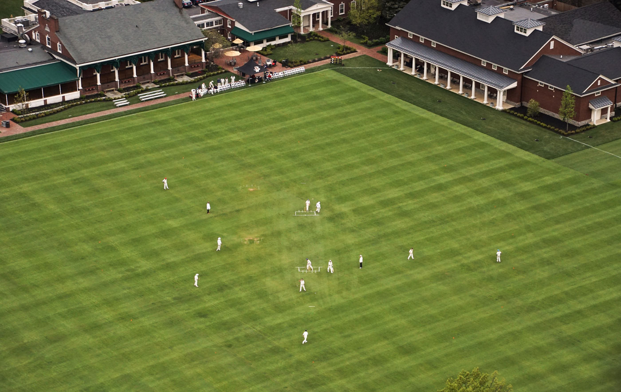

*i am going to scrap data from the webpage by two different ways.*

### Method 1

**Load rvest package**

```r
library(rvest)
```

**Reading url**

```r
cricinfo <- read_html("http://stats.espncricinfo.com/ci/engine/records/averages/batting.html?class=1;id=2016;type=year")
```

**Web scrapping**

```r
#Extract Players names
Player <- cricinfo %>% html_nodes(".data1 .left") %>% html_text()
#Extract Matches played bybatsmen
Matches <- cricinfo %>% html_nodes(".left+ td") %>% html_text()
#Extract the number of runs scored by batsmen
Runs <- Average <- cricinfo%>%html_nodes("td:nth-child(5)")%>%html_text()
#Extract highest scores by batsmen
Highestscore <- cricinfo %>% html_nodes("td:nth-child(6)") %>% html_text()
#Extract batting average's of the batsmen
Average <- cricinfo%>%html_nodes("td:nth-child(7)")%>%html_text()
# Creat a data frame with the above varaibles
cricinfo_table <- data.frame(Player,Matches,Runs,Highestscore,Average)
#Preview dataframe
head(cricinfo_table)
```

```
##              Player Matches Runs Highestscore Average
## 1    KJ Abbott (SA)      4*   36           17    7.20
## 2      MM Ali (ENG)      17 1078         155*   46.86
## 3      HM Amla (SA)      9*  729          201   48.60
## 4  CJ Anderson (NZ)       2  150           72   37.50
## 5 JM Anderson (ENG)      12   66           17    8.25
## 6   ZS Ansari (ENG)       3   49           32    9.80
```

###### Table 1.

### Method 2

```r
#Extract the entire table(including all the rows and columns)
cricinfo1 <- cricinfo %>% html_nodes("table") %>% .[[1]] %>% html_table()
#Preview dataframe
head(cricinfo1)
```

```
##              Player Mat Inns NO Runs   HS   Ave   BF    SR 100 50 0  4s 6s
## 1    KJ Abbott (SA)  4*    5  0   36   17  7.20  100 36.00   0  0 2   2  1
## 2      MM Ali (ENG)  17   29  6 1078 155* 46.86 2004 53.79   4  5 3 116 11
## 3      HM Amla (SA)  9*   15  0  729  201 48.60 1421 51.30   2  3 1 101  2
## 4  CJ Anderson (NZ)   2    4  0  150   72 37.50  323 46.43   0  1 1  19  4
## 5 JM Anderson (ENG)  12   15  7   66   17  8.25   99 66.66   0  0 3   9  0
## 6   ZS Ansari (ENG)   3    5  0   49   32  9.80  136 36.02   0  0 2   5  0
```

###### Table 2.

### Method 1 vs Method 2

With method 1, there is visibly more numbers of lines of code have been used. However, this way gives more control over picking the columns that you need to carry out data analysis. Out Of the 14 variables or columns in the table, i have selectively picked 5 columns (Table 1).This method also requires a few additional steps, that includes using [SelectorGadget](http://selectorgadget.com/),an open source tool that makes CSS selector generation and discovery.Method 2, on the other hand, has only a single line of code.However, the entire table including all the columns are scrapped (Table 2).